# Homework_002

Michael James

February 24, 2019

```r
library(readr)
(LeafData <- read_delim("LeafData.tsv","\t", escape_double = FALSE, trim_ws = TRUE))
```

```
## # A tibble: 144 x 6
##    PARK  `LIFE STAGE` HEIGHT `LEAF NUMBER` `LEAF L` `LEAF W`
##    <chr> <chr>         <dbl>         <dbl>    <dbl>    <dbl>
##  1 HAWN  JUVENILE       27               4     16        6.8
##  2 HAWN  JUVENILE       33.7             6     17        7.5
##  3 HAWN  JUVENILE       13.5             4     10.1      3.8
##  4 HAWN  JUVENILE        6.3             3      5.4      2
##  5 HAWN  JUVENILE        2.5             2      2.6      1.1
##  6 HAWN  JUVENILE        5               2      4.7      1.8
##  7 HAWN  JUVENILE        5.1             3      5.6      2.2
##  8 HAWN  JUVENILE        3.1             2      3.1      0.6
##  9 HAWN  JUVENILE        5.2             2      6.8      1.8
## 10 HAWN  JUVENILE        3.7             2      2.9      0.7
## # ... with 134 more rows
```

```r
summary(LeafData)
```

```
##      PARK            LIFE STAGE            HEIGHT       LEAF NUMBER
##  Length:144         Length:144         Min.   : 0.70   Min.   :1.000
##  Class :character   Class :character   1st Qu.: 8.65   1st Qu.:3.000
##  Mode  :character   Mode  :character   Median :18.85   Median :4.500
##                                        Mean   :22.91   Mean   :4.444
##                                        3rd Qu.:35.65   3rd Qu.:6.000
##                                        Max.   :59.00   Max.   :7.000
##      LEAF L          LEAF W
##  Min.   : 1.80   Min.   : 0.400
##  1st Qu.: 7.80   1st Qu.: 2.675
##  Median :12.00   Median : 5.500
##  Mean   :11.08   Mean   : 5.161
##  3rd Qu.:14.70   3rd Qu.: 7.600
##  Max.   :18.50   Max.   :10.300
```

```r
# Make sure to attach the data so you can reference the headers
attach(LeafData)
```

# Question 1:

## Leaf Number with Respect to the Park

### Justification

A little *a priori* knowledge from this benevolent overlord guy that Hawn SP had a fire, thus clearing the way for smaller plants to flourish, leads me to assume that – in general – more trees in St. Francis are going to be larger and have more leaves that the mostly younger trees of Hawn.

Seeing as the two datasets will likely have vastly different variances, I’m going to go with the Welch Two Sample t-test.

### Results

```r
t.test(`LEAF NUMBER`~PARK)
```

```
##
##  Welch Two Sample t-test
##
## data:  LEAF NUMBER by PARK
## t = 0.051541, df = 74.457, p-value = 0.959
## alternative hypothesis: true difference in means is not equal to 0
## 95 percent confidence interval:
##  -0.6154111  0.6480975
## sample estimates:
##    mean in group HAWN mean in group ST FRAN
##              4.454545              4.438202
```

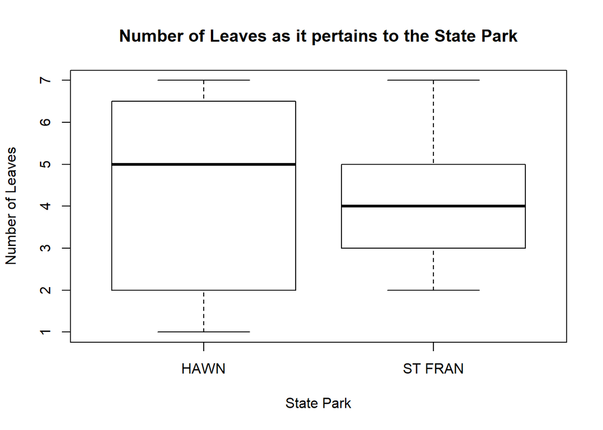

```r
# Boxplot
boxplot(`LEAF NUMBER`~PARK, xlab="State Park", ylab = "Number of Leaves", main = "Number of Leaves as it pertains to the State Park")
```

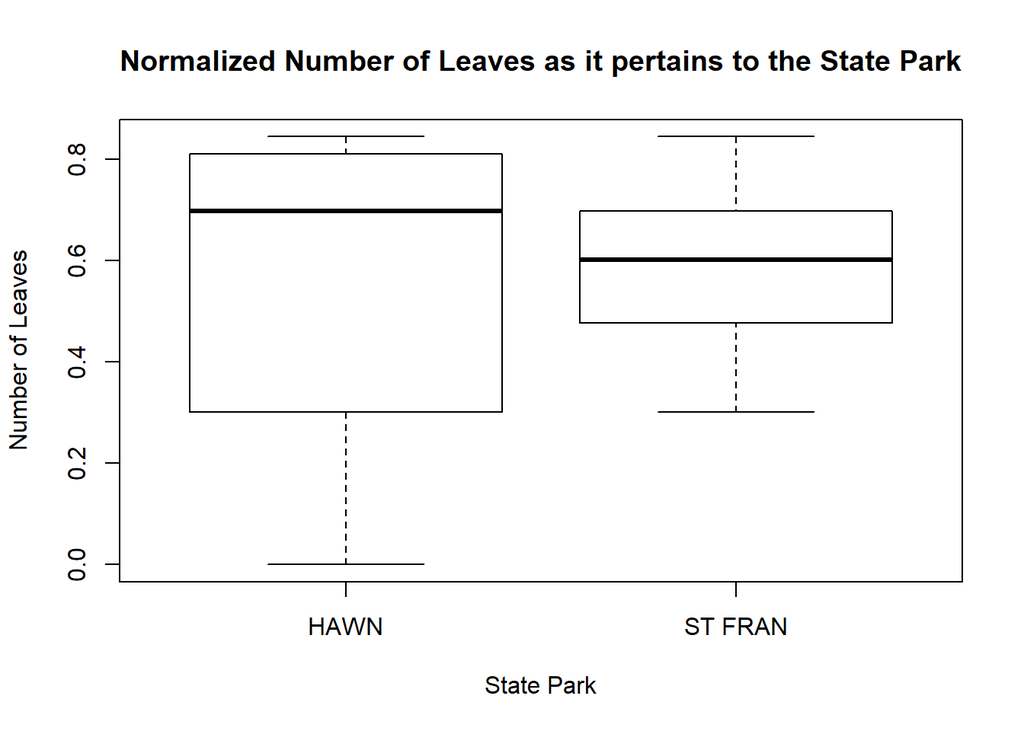

```r
boxplot(log10(`LEAF NUMBER`)~PARK, xlab="State Park", ylab = "Number of Leaves", main = "Normalized Number of Leaves as it pertains to the State Park")
```

```r
# Looking at a normalized t-test
t.test(log10(`LEAF NUMBER`)~PARK)
```

```
##
##  Welch Two Sample t-test
##
## data:  log10(`LEAF NUMBER`) by PARK
## t = -1.2042, df = 71.791, p-value = 0.2325
## alternative hypothesis: true difference in means is not equal to 0
## 95 percent confidence interval:
##  -0.11386583  0.02810824
## sample estimates:
##    mean in group HAWN mean in group ST FRAN
##             0.5874143             0.6302931
```

# Question 2:

## Leaf Width with Respect to the Life Stage

### Justification

For this dataset, I’m going with the Wilcoxon test. I chose this because I would venture to guess that leaf width based on the life stage of the trees shouldn’tt have anything to do with where it’s located; it should be specific to the species of tree.

### Results

```r
# Wilcoxon
wilcox.test(`LEAF W`~`LIFE STAGE`)
```

```
##
##  Wilcoxon rank sum test with continuity correction
##
## data:  LEAF W by LIFE STAGE
## W = 323.5, p-value = 4.037e-16
## alternative hypothesis: true location shift is not equal to 0
```

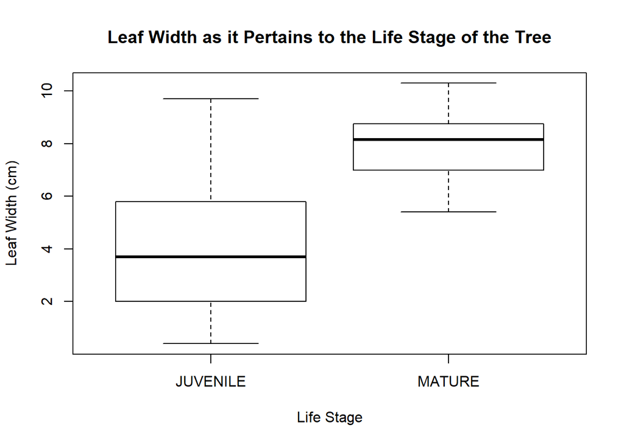

```r
# Boxplot
boxplot(`LEAF W`~`LIFE STAGE`, xlab="Life Stage", ylab = "Leaf Width (cm)", main = "Leaf Width as it Pertains to the Life Stage of the Tree")
```

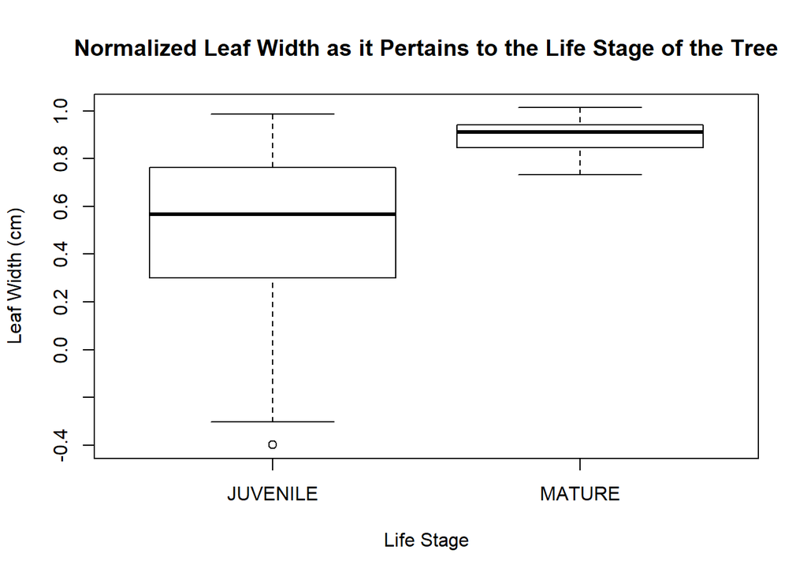

```r
boxplot(log10(`LEAF W`)~`LIFE STAGE`, xlab="Life Stage", ylab = "Leaf Width (cm)", main = "Normalized Leaf Width as it Pertains to the Life Stage of the Tree")
```

### Conclusion

The calculated p-value is **very** small, leading me to argue for the rejection of the null hypothesis and state that leaf width is a function of the maturity of the tree.

Looking at the two sets of box plots, the first plot, you have a wide range of leaf widths for the juveniles (some trees are bigger than others for their respective life stages) with an overall mean that is near 4, while the mature trees have, as *I* would expect, larger leaves.

The second plot is the normalized data, which does not show anything significantly different, letting me know that using the Wilcoxon test was the right choice as it does not require normalization of the data.